# Modulo 7: Exploratory Factor Analysis - EFA

Ottavia M. Epifania, Margherita Calderan

# Matrice di correlazione

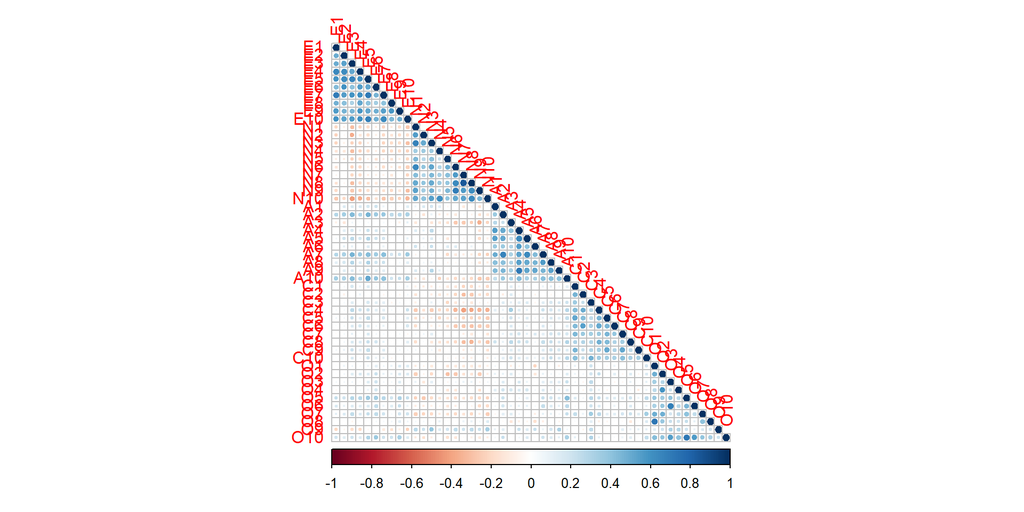

# L’analisi fattoriale esplorativa

Considerando $i = 1, \ldots I$ le variabili manifeste (item) e $p = 1, \ldots, P$ e assumendo $\theta$ come fattore latente unidimensionale:

$$Y_{pi} = \mu_{i} + \lambda_i \theta_p + \varepsilon_{ip}$$
dove

$\mu_i$: è l’intercetta per l’$i$-esimo indicatore

$\theta_p$: è il livello di tratto latente *non osservator* per il $p$-esimo soggetto

$\lambda_i$: è il *factor loading* (saturazione) dell’$i$-esimo indicatore che descrive la forza della correlazione tra l’indicatore $i$ e il tratto latente $\theta$

## Più dimensioni

$\theta_1, \ldots, \theta_F$, presupponendo che comunque $F < I$:

$$Y_{pi} = \mu_{i} + \lambda_{i1} \theta_{p1} + \ldots + \lambda_{iF} \theta_{pF} + \varepsilon_{ip}$$

**Assunzioni**

$\theta_p$ e $\varepsilon_{pi}$ sono indipendenti tra loro

$\varepsilon_{pi} \sim \mathcal{N}(0, 1)$ per cui $E(\varepsilon_{pi}) = 0$

$\theta \sim \mathcal{N}(0, 1)$ per cui $E(\theta_p) = 0$ e $var(\theta_p) = 1$

Date queste assunzioni:

$Y_{p1} \ldots Y_{pI}$ sono localmente indipendenti **data** la variabile latente $\theta_p$

La varianza di ogni variabile manifesta viene partizionata in:

**Comunalità $h^2$**

Porzione della varianza della variabile manifesta che è spiegata dal fattore latente:

- Modello unidimensionale: $h_i^2 = \lambda_i^2$
- Modello multifattoriale con $F$ fattori: $h_i^2 = \sum_{f = 1}^{F} \lambda_{if}^2$

**Unicità $u_i^2$**

La varianza della variabile manifesta che non è spiegata dal modello fattoriale (a uno o più fattori)

$u_i^2 = 1 -h_i^2$

I parametri del modello ($\lambda_i$, $h_i^2$, $u_i^2$) possono essere stimati a partire dalla semplice matrice di correlazione osservata

Per estrarre i *factor scores* (il punteggio pesato in base ai $\lambda_i$ per ogni soggetto $p$), valutare la fit del modello e fare inferenza è necessario avere a disposizione la numerosità campionaria e i vettori delle risposte fornite ad ogni item

# Step preliminari

**La domanda**

Ci sono delle correlazioni tra gli item?

**Test di sfericità di Bartlett**

Verifica se la matrice di correlazione $\mathbf{R}$ è significativamente diversa da una matrice identità $\mathbf{I}$ (ovvero una matrice dove è prevista l’indipendenza tra tutte le variabili).

$H_0: \mathbf{R} = \mathbf{I} \qquad H_1: \mathbf{R} \neq \mathbf{I}$

$$\chi^2 = - (n-1 - \dfrac{2I + 5}{6}) \ln |\mathbf{R}| \qquad \text{con} \quad df = \dfrac{I(I-1)}{2}$$
con $n$ ampiezza campionaria, $I$ numero di item e $|\mathbf{R}|$ determinante di $\mathbf{R}$

## Un esempio

$n = 50$

$$\mathbf{R} = \begin{pmatrix}
1 & 0.6 \\
0.6 & 1
\end{pmatrix}$$

$$\mathbf{I} = \begin{pmatrix}
1 & 0 \\
0 & 1
\end{pmatrix}$$

Determinante: $|\mathbf{R}|=1\cdot 1−0.6^2=1−0.36=0.64$

$\chi^2 = - (n-1 - \dfrac{2I + 5}{6}) \ln |\mathbf{R}| = - (50-1 - \dfrac{2\cdot2 + 5}{6}) \ln 0.64 = \approx 21.2$

$\dfrac{I(I-1)}{2} = \dfrac{2(2-1)}{2} = 1$

$p$-value$ = 4.1376451^{-6}$

```
$chisq
[1] 16877.21

$p.value
[1] 0

$df
[1] 1225
```

**La domanda**

Le correlazioni sono spiegabili dalle variabili latenti?

**Kayser-Meyer-Olkin**

Misura dell’adeguatezza dei dati per l’analisi fattoriale prendendo in considerazione le *correlazioni parziali* (le correlazioni che rimangono una volta tolto l’effetto delle variabili latenti) degli item

$$KMO = \frac{\sum_{i \ne j} r_{ij}^2}{\sum_{i \ne j} r_{ij}^2 + \sum_{i \ne j} p_{ij}^2}$$

con:

$r_{ij}$: Correlazione tra $i,j$ (con $i, j = 1, \ldots, I$ e $i \ne j$)

$p_{ij} = -\frac{\omega_{ij}}{\sqrt{\omega_{ii}\,\omega_{jj}}} \quad \text{con} \quad \Omega = R^{-1}$: Correlazione parziale tra $i, j$ (controllando per tutte le altre, ovvero *quanto resta della relazione tra due variabili dopo aver tolto tutto il resto*)

$KMO > .90$: Ottimo, $KMO > .70$: Accettabile

## Un esempio

$$\mathbf{R} =
\begin{pmatrix}
1 & 0.6 & 0.5 \\
0.6 & 1 & 0.4 \\
0.5 & 0.4 & 1
\end{pmatrix}$$

$r_{12}^2 = 0.36, \quad r_{13}^2 = 0.25, \quad r_{23}^2 = 0.16$

$\sum r_{ij}^2 = 0.36 + 0.25 + 0.16 = 0.77$

$$\Omega = \mathbf{R}^{-1} \approx
\begin{pmatrix}
1.56 & -0.88 & -0.43 \\
-0.88 & 1.45 & -0.22 \\
-0.43 & -0.22 & 1.29
\end{pmatrix}$$

con $p_{ij} = -\frac{\omega_{ij}}{\sqrt{\omega_{ii}\,\omega_{jj}}}$ si ottengono:

$p_{12} = -\frac{\omega_{12}}{\sqrt{\omega_{11}\,\omega_{22}}} = -\frac{-0.88}{\sqrt{1.56 \cdot 1.45}} \approx 0.59$

$p_{13} = -\frac{\omega_{13}}{\sqrt{\omega_{11}\,\omega_{33}}} = -\frac{-0.43}{\sqrt{1.56 \cdot 1.29}} \approx 0.30$

$p_{23} = -\frac{\omega_{23}}{\sqrt{\omega_{22}\,\omega_{33}}} = -\frac{-0.22}{\sqrt{1.45 \cdot 1.29}} \approx 0.16$

$\sum p_{ij}^2 = 0.59^2 + 0.30^2 + 0.16^2 \approx 0.47$

$$KMO = \frac{\sum r_{ij}^2}{\sum r_{ij}^2 + \sum p_{ij}^2} = \frac{0.77}{0.77 + 0.47} \approx 0.62$$

```
Kaiser-Meyer-Olkin factor adequacy
Call: KMO(r = mycor$rho)
Overall MSA =  0.84
MSA for each item =
  E1   E2   E3   E4   E5   E6   E7   E8   E9  E10   N1   N2   N3   N4   N5   N6
0.88 0.85 0.93 0.91 0.88 0.87 0.89 0.83 0.86 0.88 0.88 0.78 0.85 0.76 0.85 0.83
  N7   N8   N9  N10   A1   A2   A3   A4   A5   A6   A7   A8   A9  A10   C1   C2
0.77 0.79 0.86 0.85 0.88 0.84 0.84 0.85 0.87 0.79 0.86 0.92 0.87 0.89 0.86 0.83
  C3   C4   C5   C6   C7   C8   C9  C10   O1   O2   O3   O4   O5   O6   O7   O8
0.83 0.92 0.83 0.83 0.86 0.85 0.80 0.85 0.74 0.78 0.67 0.75 0.85 0.73 0.85 0.65
  O9  O10
0.80 0.83
```

# Estrarre le dimensioni latenti

**La domanda**

Di quante dimensioni latenti ho bisogno per spiegare le relazioni?

| Metodo | Logica |
| --- | --- |
| Kaiser (eigenvalue > 1) | soglia fissa |
| Scree | plot giudizio visivo |
| Parallel analysis | confronto con dati casuali |
| MAP | minimizzazione del residuo |

**Eigenvalue (Autovalore)**

Misura quanta della varianzaz totale della matrice di correlazione è catturata da ogni fattore $f$

Viene estratto un numero $f^*$ di fattori latenti per ogni autovalore $\geq 1$ (Metodo di Kaiser, 1960) $\rightarrow$ seleziona i fattori che spiegano più varianza di una singola variabile standardizzata.

- Autovalori
- Graficamente

```
 [1] 9.84142742 5.52833703 4.63300629 3.98118880 3.09613112 1.62580346
 [7] 1.33397237 1.09079845 1.08873790 1.01248198 0.93733631 0.90653967
[13] 0.86050342 0.78803527 0.73620908 0.71703912 0.67000442 0.64882836
[19] 0.63511334 0.59212244 0.56075330 0.53939501 0.52017805 0.49129695
[25] 0.47730219 0.42582534 0.42415278 0.41785459 0.40360001 0.37650095
[31] 0.35726114 0.35269216 0.33754745 0.33267729 0.29979759 0.29565488
[37] 0.28938009 0.26655103 0.24926235 0.23875991 0.23286216 0.21192470
[43] 0.20808190 0.18809221 0.16309109 0.15240343 0.14498990 0.13100540
[49] 0.10360982 0.08388006
```

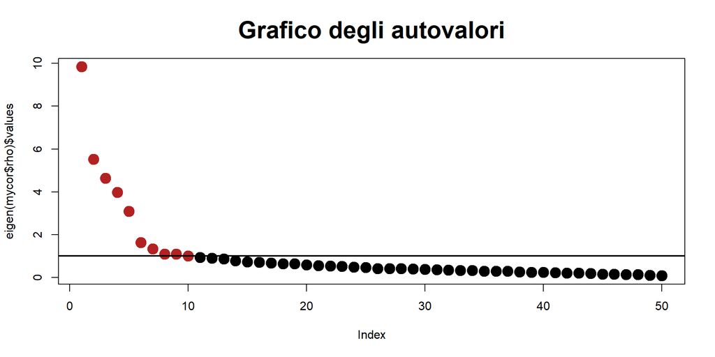

**Scree plot (Cattell, 1966)**

Vengono estratti gli $f$ fattori estraibili (dove $F = I$) sull’asse delle x mentre sull’asse delle y vengono plottati gli autovalori associati ad ognuno dei fattori.

Tutto basato sul giudizio visivo di dove si forma la curva a gomito: Si estraggono un numero di fattori tanti quanti sono i fattori sopra il gomito

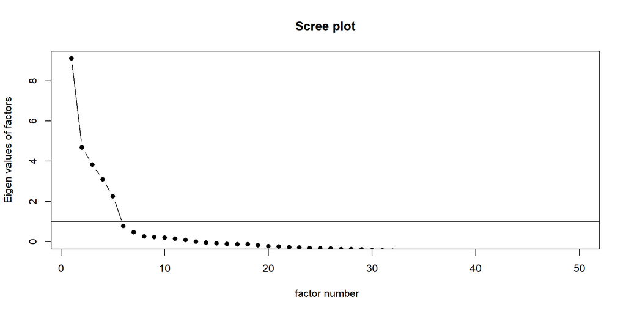

**Parallel analysis (Horn, 1965)**

Vengono confrontati gli autovalori estratti dai dati con gli autovalori estratti da dei dati completamente casuali.

Si estraggono tante dimensioni quante sono le dimensioni osservate oltre le dimensioni casuali

```
Parallel analysis suggests that the number of factors =  7  and the number of components =  NA
```

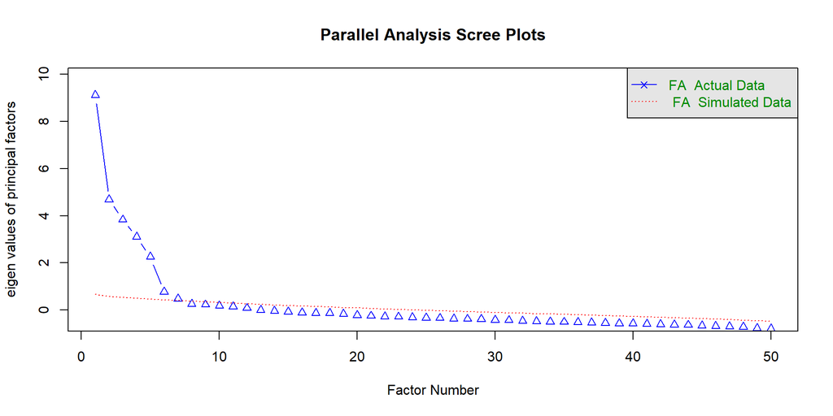

**Minimum Average Partial (MAP)**

Misura quanta varianza residua rimane dopo aver rimosso progressivamente fattori

Sceglie la soluzione che permette di *minimizzare* la varianza residua

$$MAP(f) = \dfrac{1}{m} \sum_{i \ne j} r_{ij}^{(f)}^2$$
$m$: Numero di coppie di variabili

$r_{ij}^{(f)}$ correlazione parziale tra ogni coppia di variabili dopo aver estratto $f$ fattori

$$f^* = \arg \min_f MAP(f)$$

[output not shown]

# Indici di fit

Per scegliere il “miglior” modello di EFA, vanno confrontate diverse soluzioni che prendano in considerazione diversi modelli fattoriali

**Indici comparativi**

Akaike’s Information Criterion: $AIC = 2g - 2 \log(\mathcal{L})$

Bayesian Information Criterion: $BIC = g\log(n) - 2 \log(\mathcal{L})$

$g$: Numero di parametri liberi stimati dal modello

$\mathcal{L}$: Funzione di verosimiglianza del modello

$n$: ampiezza campionaria

AIC e BIC sono indici di entropia: Minore è il loro valore, meglio è la fit del modello

Penalizzano modelli troppo complessi

**Test $\chi^2$ (Goodness-of-fit)**

Basato sulla verosimiglianza $\mathcal{L}$ ottenuta dal confronto tra la matrice di covarianza osservata e la matrice di covarianza attesa ($cov$) secondo il modello fattoriale ($\hat{cov}$)

$H_0$: $cov = \hat{cov}$

$df$: Numero di elementi nella matrice di covarianza $-$ numnero di parametri stimati (saturazioni, correlazioni tra fattori ecc.)

Molto sensibile all’ampiezza campionaria! **Non** deve essere l’unica statistica a guidare la scelta del modello

**Root mean square error of approximation (RMSEA)**

Indice di fit assoluto basato sul $\chi^2$:

$RMSEA = \dfrac{\chi^2 -df}{df(n-1)}$

$E(\chi^2) = df$ $\rightarrow$ più è piccolo il valore di RMSEA, minore è l’errore, migliore è il modello

$RMSEA < .10$ fit accettabile

$RMSEA < ..05$ fit ottima

Viene definito indice comparativo ma non con lo stesso significato degli indici di entropia (AIC e BIC)

**Comparative Fit Index (CFI)**

Confronta la performance del modello target ($T$) e di un modello baseline ($B$) in cui tutte le covarianze sono fissate a 0 (non c’è correlazione tra le variabili manifeste) e le varianze sono stimate liberamente a partire dai dati:

$$CFI = \dfrac{(\chi_B^2 - df_B) - (\chi_T^2 - df_T)}{(\chi_B^2 - df_B)}$$

Se il modello $T$ è correttamente specificato: $(\chi_T^2 - df_T) \approx 0 \rightarrow CFI \approx 1$

$CFI \geq .90$ Valori accettabili

$CFI \geq .95$ Valori ottimali

**Attenzione!!!**

Il CFI è un indice che è stato pensato per modelli confermativi

In EFA viene usato in senso compartivo, nel senso di vedere come cambia la fit del modelo in base al numero di fattori inseriti nel modello fattoriale

## Oltre gli indici

Per valutare la buona fit di un modello fattoriale esplorativo vanno tenuti a mente i principi di:

- Causazione: Varianza spiegata da/dai fattore/i latenti
- Parsimonia: Non aggiungere fattori non necessari
- Struttura semplice: Almeno 3 item per fattore e nessun cross-loading

```
  Estimator                                       DWLS
  Rotation method                      OBLIMIN OBLIQUE
  Oblimin gamma                                      0
  Rotation algorithm (rstarts)                GPA (30)
  Standardized metric                             TRUE
  Row weights                                     None

  Number of observations                           538

Overview models:
                  chisq   df pvalue   cfi rmsea
  nfactors = 4 4406.781 1031      0 0.687 0.096
  nfactors = 5 2792.016  985      0 0.787 0.081
  nfactors = 6 2256.067  940      0 0.819 0.076

Eigenvalues correlation matrix:

     ev1      ev2      ev3      ev4      ev5      ev6      ev7      ev8
  9.8413   5.5283   4.6330   3.9812   3.0962   1.6258   1.3340   1.0908
     ev9     ev10     ev11     ev12     ev13     ev14     ev15     ev16
  1.0887   1.0125   0.9373   0.9065   0.8605   0.7881   0.7362   0.7170
    ev17     ev18     ev19     ev20     ev21     ev22     ev23     ev24
  0.6700   0.6488   0.6351   0.5921   0.5607   0.5394   0.5202   0.4913
    ev25     ev26     ev27     ev28     ev29     ev30     ev31     ev32
  0.4773   0.4259   0.4242   0.4178   0.4036   0.3765   0.3573   0.3527
    ev33     ev34     ev35     ev36     ev37     ev38     ev39     ev40
  0.3376   0.3327   0.2998   0.2956   0.2894   0.2666   0.2493   0.2387
    ev41     ev42     ev43     ev44     ev45     ev46     ev47     ev48
  0.2329   0.2119   0.2081   0.1881   0.1631   0.1524   0.1450   0.1310
    ev49     ev50
  0.1036   0.0839

Number of factors:  4

Standardized loadings: (* = significant at 1% level)

        f1      f2      f3      f4       unique.var   communalities
E1   0.770*                                   0.406           0.594
E2   0.716*       *      .*                   0.464           0.536
E3   0.606*      .*      .*                   0.441           0.559
```

[output cut: 240 more lines]

```
                              f1    f2    f3    f4    f6    f5  total
Sum of sq (obliq) loadings 6.186 5.639 4.965 4.249 3.190 2.657 26.884
Proportion of total        0.230 0.210 0.185 0.158 0.119 0.099  1.000
Proportion var             0.124 0.113 0.099 0.085 0.064 0.053  0.538
Cumulative var             0.124 0.236 0.336 0.421 0.485 0.538  0.538

Factor correlations: (* = significant at 1% level)

       f1      f2      f3      f4      f5      f6
f1  1.000
f2 -0.232*  1.000
f3  0.164*  0.016   1.000
f4  0.113* -0.206*  0.182*  1.000
f5  0.010  -0.025   0.004   0.046   1.000
f6  0.227* -0.077   0.119*  0.062   0.242*  1.000
```

## Indici di fit

```
                chisq   df pvalue   cfi rmsea
nfactors = 4 4406.781 1031      0 0.687 0.096
nfactors = 5 2792.016  985      0 0.787 0.081
nfactors = 6 2256.067  940      0 0.819 0.076
```

Riporta la model comparison tra i modelli:

`chisq`: Chi-quadro del modello (testa l’ipotesi nulla per cui i dati si conformano al modello con $F$ fattori)

`df`: gradi di libertà del modello

`pvalue`: p-value associato al chi quadro

`cfi`: Va interpretato in maniera comparitiva, non assoluta!

`rmsea`: Interpretato sia in maniera comparativa che assoluta

## Soluzione a 4 fattori

- Varianza spiegata

```
                              f2    f1    f3    f4  total
Sum of sq (obliq) loadings 6.638 6.470 5.780 4.655 23.542
Proportion of total        0.282 0.275 0.246 0.198  1.000
Proportion var             0.133 0.129 0.116 0.093  0.471
Cumulative var             0.133 0.262 0.378 0.471  0.471
```

```
        E1     E2     E3     E4     E5     E6     E7     E8     E9    E10
E1   0.000
E2  -0.045  0.000
E3  -0.026  0.041  0.000
E4   0.054  0.083 -0.046  0.000
E5   0.004  0.044  0.063 -0.023  0.000
E6  -0.038  0.134 -0.045  0.067 -0.031  0.000
E7   0.091 -0.023  0.021 -0.016  0.048 -0.047  0.000
E8   0.012  0.007 -0.073  0.057 -0.039 -0.035 -0.060  0.000
E9   0.030 -0.032 -0.003  0.054 -0.013  0.025 -0.005  0.157  0.000
E10  0.015  0.007  0.012  0.020  0.084  0.002  0.038 -0.003 -0.039  0.000
N1   0.063  0.065  0.002  0.082  0.045  0.054  0.036  0.121  0.065  0.068
N2   0.023  0.115 -0.109  0.136  0.030  0.086  0.037  0.070  0.052  0.113
N3   0.050  0.045  0.036  0.054  0.063  0.059  0.008  0.045  0.052  0.023
N4   0.086  0.027 -0.035  0.035  0.046  0.053  0.030  0.000  0.014  0.053
N5   0.086  0.005  0.017  0.039  0.111 -0.019  0.090  0.007  0.066  0.036
N6   0.075  0.104  0.082  0.058  0.126  0.037  0.034  0.072  0.013  0.059
N7   0.060 -0.019  0.062  0.011  0.046 -0.036  0.064 -0.038  0.037  0.008
N8   0.016  0.002  0.015  0.043  0.028 -0.036  0.066 -0.007  0.003  0.068
N9   0.035  0.157  0.080  0.066  0.102  0.055  0.092 -0.011  0.057  0.016
N10  0.059  0.023 -0.006  0.011  0.043  0.050  0.070  0.011  0.031  0.074
A1  -0.106 -0.033 -0.074  0.004 -0.099  0.031 -0.114 -0.005 -0.092  0.014
A2  -0.065 -0.072  0.022 -0.099 -0.048 -0.022 -0.056  0.024 -0.032 -0.043
A3  -0.070 -0.158 -0.100 -0.039 -0.103 -0.049 -0.028  0.014 -0.038  0.043
A4  -0.080 -0.085 -0.078 -0.062 -0.113 -0.031 -0.073 -0.031 -0.033 -0.071
A5  -0.108 -0.053 -0.024 -0.039 -0.076 -0.034 -0.086 -0.094 -0.086 -0.083
A6  -0.042 -0.045 -0.044 -0.066 -0.066 -0.099 -0.045  0.028  0.023 -0.090
A7  -0.053 -0.094  0.006 -0.045 -0.115 -0.037 -0.032 -0.033 -0.067 -0.007
A8  -0.028 -0.059  0.004 -0.056 -0.047 -0.036 -0.032 -0.074 -0.063 -0.053
A9  -0.012 -0.052 -0.049 -0.038 -0.068 -0.059 -0.053 -0.010  0.008 -0.092
A10  0.018 -0.035  0.006 -0.081  0.035  0.032  0.005 -0.025 -0.061 -0.017
C1   0.111  0.124  0.065  0.080  0.079  0.029  0.062  0.043  0.111  0.066
C2   0.106  0.079 -0.024  0.140  0.025  0.083  0.046  0.089  0.082  0.096
C3   0.082  0.048  0.040  0.004  0.061  0.031  0.095 -0.017  0.040 -0.012
C4   0.019  0.027  0.035  0.092  0.038  0.043  0.030  0.040  0.023  0.088
C5   0.095  0.081  0.052  0.069  0.129 -0.021  0.133  0.069  0.034  0.076
C6   0.075  0.098  0.014  0.147  0.057  0.047  0.075  0.045  0.057  0.128
C7   0.085  0.110  0.027  0.074  0.110  0.063  0.072  0.131  0.164 -0.002
C8   0.010  0.023 -0.038  0.056  0.049  0.094  0.017 -0.014 -0.011  0.024
C9   0.104  0.095  0.101  0.100  0.140 -0.053  0.124  0.077  0.127  0.022
```

[output cut: 200 more lines]

```
C6
C7
C8
C9
C10
O1   0.000
O2  -0.020  0.000
O3  -0.146 -0.107  0.000
O4  -0.104  0.284 -0.107  0.000
O5  -0.111 -0.111 -0.030 -0.073  0.000
O6  -0.167 -0.029  0.245 -0.056 -0.007  0.000
O7   0.049  0.084 -0.166 -0.028 -0.032 -0.137  0.000
O8   0.166 -0.038 -0.216 -0.122 -0.159 -0.310  0.058  0.000
O9  -0.061  0.052  0.030  0.093  0.048 -0.112  0.046 -0.021  0.000
O10 -0.145 -0.100  0.038  0.020  0.150  0.038 -0.061 -0.161  0.001  0.000
```

Sum of sq (obliq) loadings: Somma dei quadrati dei loadings fattoriali

Proportion of total: Proporzione della varianza spiegata DAI FATTORI LATENTI (somma a 1)

Proportion var: Percentuale di varianza totale osservata spiegata da ogni fattore

Cumulative var: Varianza totale spegata cumulativa

```
                              f2    f1    f3    f4  total
Sum of sq (obliq) loadings 6.638 6.470 5.780 4.655 23.542
Proportion of total        0.282 0.275 0.246 0.198  1.000
Proportion var             0.133 0.129 0.116 0.093  0.471
Cumulative var             0.133 0.262 0.378 0.471  0.471
```

```
                              f1    f2    f3    f5    f4  total
Sum of sq (obliq) loadings 6.254 5.725 5.084 4.467 4.168 25.698
Proportion of total        0.243 0.223 0.198 0.174 0.162  1.000
Proportion var             0.125 0.114 0.102 0.089 0.083  0.514
Cumulative var             0.125 0.240 0.341 0.431 0.514  0.514
```

```
                              f1    f2    f3    f4    f6    f5  total
Sum of sq (obliq) loadings 6.186 5.639 4.965 4.249 3.190 2.657 26.884
Proportion of total        0.230 0.210 0.185 0.158 0.119 0.099  1.000
Proportion var             0.124 0.113 0.099 0.085 0.064 0.053  0.538
Cumulative var             0.124 0.236 0.336 0.421 0.485 0.538  0.538
```

L’aggiunta del 6 fattore non aggiunge molto al modello: Parsimonia!

# Matrice delle saturazioni